# MidTerm Decision

June 12, 2019

### Background

For this analysis, our professor Brother Saunders wants us to decide whether we will keep or drop our MidTerm score based off of our Final Exam score. More than that, he wants us to create a regression with a dataset that has other variables in it. He wants us to create a model that can accurately predict **our own exam score**, not just a broad spectrum of exam scores. That would be useless. To decide if it is worth it, I will be looking at a stipulation Brother Saunders has setup for our decision:

- **Drop midterm:** your “Exam” grade in Canvas will be entirely based on your Final Exam score.
- **Keep midterm:** your “Exam” grade in Canvas will be the weighted average of your Final Exam (70%) and Midterm (30%) scores, i.e., 0.7 x Final + 0.3 x Midterm.

Here are the steps I went through to get to my final conclusion

### Step 1: Original Analysis

I first started off looking at simple linear regression. Here is what my model looked like:

$$\underbrace{Y_i}_\text{Final Score} = \beta_0 + \beta_1 \underbrace{X_i}_\text{MidTerm Score} + \epsilon_i \quad \text{where} \ \epsilon_i \sim N(0,\sigma^2)$$

I busted out a graph to see the data and I saw a couple outliers and took them out. Here is what it looks like:

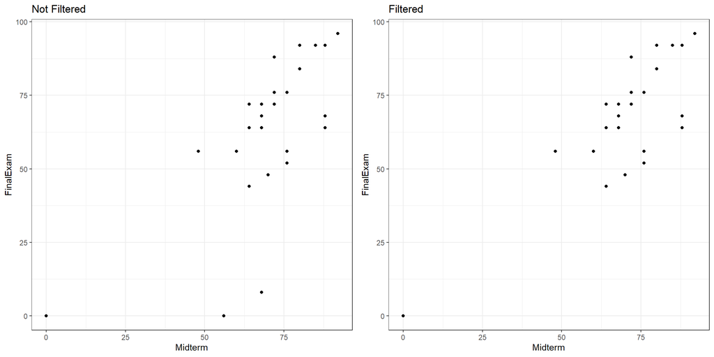

```r
plot_1 <- exam_scores %>%
  ggplot(aes(x = Midterm, y = FinalExam)) +
  geom_point() +
  labs(title = "Not Filtered") +
  theme_bw()

plot_2 <- exam_scores_filtered %>%
  ggplot(aes(x = Midterm, y = FinalExam)) +
  geom_point() +
  labs(title = "Filtered") +
  theme_bw()

plot_grid(plot_1, plot_2)
```

I kept the zero and zero because I felt it could help make my regression more linear. I then ran a summary and got the following results:

```r
exam_lm <- lm(FinalExam ~ Midterm, data = exam_scores_filtered)
pander(summary(exam_lm))
```

|  | Estimate | Std. Error | t value | Pr(>\|t\|) |
| --- | --- | --- | --- | --- |
| **(Intercept)** | 2.895 | 7.657 | 0.3781 | 0.7087 |
| **Midterm** | 0.9277 | 0.1084 | 8.559 | 9.35e-09 |

Fitting linear model: FinalExam ~ Midterm

| Observations | Residual Std. Error | $R^2$ | Adjusted $R^2$ |
| --- | --- | --- | --- |
| 26 | 12.06 | 0.7532 | 0.743 |

I thought an R-squared value of 0.7532 was pretty good and the slope p-value was highly signficant, but I felt I could do better, so I made a pairs plot to see if there were any trends.